# Costs of Exercise versus Exercise-Plus interventions on falls

RSF

2022-08-17

# 1) Data set-up and management

Load Packages

```r
if (!require("pacman")) install.packages("pacman")
```

```r
pacman::p_load(readxl, plyr, robumeta,metafor, clubSandwich, ggplot2, psych, naniar)
```

Import and Prep Data for Meta-Analysis

```r
setwd("~/Desktop/Manuscripts/Ongoing Projects/Cost Analysis of Unimodal vs. Multimodal Exercise Interventions for Fall Prevention")#Directory where you put the spreadsheet
meta_data <- read_excel("META FINAL FINAL.xlsx")

spaceless <- function(x) {colnames(x) <- gsub(" ", "_", colnames(x));x}
meta_data_spaceless <- spaceless(meta_data)

data1<-meta_data_spaceless %>% replace_with_na_all(condition = ~.x == "NR")
data2<-subset(data1, Exclude=="No")

library(dplyr)
```

```r
data3<-rename(data2, "Sample_size"="Total_number_of_participants","Intervention_Type"="Intervention_Type_(EX,_EX-PluS)",
              "Intervention_Mode"="Intervention_Mode_(AT,_RT,_Multimodal)", "Intervention_Frequency"="Intervention_Frequency_(days/week)",
              "Intervention_Duration"="Intervention_Duration_(weeks)", "Economic_Perspective"="Economic_Perspective_(Healthcare,_Societal,_Personal)",
              "Incremental_Costs"="Incremental_costs_in_2021_USD","Incremental_Costs_SE"="Incremental_costs_standard_error_in_2021_USD",
              "Estimated_Incremental_Costs_SE"="Estimated_Standard_Error_(Using_similar_study_with_similar_SE)",
              "Incremental_QOLYs_SE"="Incremental_QoLYs_standard_error_in_2021_USD","Estimated_QOLYs_SE"="Estimated_SE_for_QoLYs_(Using_study_with_similar_SE)",
              "IRR_of_Falls"="Mean_Difference_in_IRR_of_Falls", "IRR_of_Falls_SE"="IRR_Standard_Error_of_estimate",
              "Estimated_IRR_of_Falls_SE"="Estimated_SE_of_IRR", "INT_N"="Treatment_group_sample_size", "CON_N"="Control_group_sample_size")


data4<-data3 %>%
  mutate(
    Incremental_Costs_SE_Final = case_when(
      !is.na(Incremental_Costs_SE) ~ Incremental_Costs_SE,
      !is.na(Estimated_Incremental_Costs_SE) ~ Estimated_Incremental_Costs_SE
      ),
    Incremental_QOLYs_SE_Final = case_when(
      !is.na(Incremental_QOLYs_SE) ~ Incremental_QOLYs_SE,
      !is.na(Estimated_QOLYs_SE) ~ Estimated_QOLYs_SE
    ),
    IRR_of_Falls_SE_Final = case_when(
      !is.na(IRR_of_Falls_SE) ~ IRR_of_Falls_SE,
      !is.na(Estimated_IRR_of_Falls_SE) ~ Estimated_IRR_of_Falls_SE
    ),
    Incremental_Costs_SMD = Incremental_Costs/Incremental_Costs_SE_Final,
    Incremental_QOLYs_SMD = Incremental_QoLYs/Incremental_QOLYs_SE_Final,
    IRR_of_Falls_SMD = log(IRR_of_Falls),
    J = 1 - (3/(4*INT_N + CON_N - 2) - 1),
    Incremental_Costs_Variance = (Sample_size*Incremental_Costs_SE_Final),
    Incremental_QOLYs_Variance = (Sample_size*Incremental_QOLYs_SE_Final),
    Incremental_Costs_SMD_var = ((INT_N + CON_N)/(INT_N*CON_N)) + ((Incremental_Costs_SMD^2)/(2*(INT_N+CON_N))),
    Incremental_QOLYs_SMD_var = ((INT_N + CON_N)/(INT_N*CON_N)) + ((Incremental_QOLYs_SMD^2)/(2*(INT_N+CON_N))),
    IRR_of_Falls_SMD_var = ((INT_N + CON_N)/(INT_N*CON_N)) + ((IRR_of_Falls_SMD^2)/(2*(INT_N+CON_N))),
    Incremental_Costs_g = Incremental_Costs_SMD * J,
    Incremental_Costs_g_var = J^2 * Incremental_Costs_SMD_var,
    Incremental_Costs_g_se = sqrt(Incremental_Costs_g_var/Sample_size),
    Incremental_QOLYs_g = Incremental_QOLYs_SMD * J,
    Incremental_QOLYs_g_var = J^2 * Incremental_QOLYs_SMD_var,
    Incremental_QOLYs_g_se = sqrt(Incremental_QOLYs_g_var/Sample_size),
    IRR_of_Falls_g = IRR_of_Falls_SMD * J,
    IRR_of_Falls_g_var = J^2 * IRR_of_Falls_SMD_var,
    IRR_of_Falls_g_se = sqrt(IRR_of_Falls_g_var/Sample_size),
    Incremental_Costs_UL95CI = Incremental_Costs + 1.96*Incremental_QOLYs_SE_Final,
    Incremental_Costs_LL95CI = Incremental_Costs - 1.96*Incremental_QOLYs_SE_Final,
    Incremental_QOLYs_UL95CI = Incremental_QoLYs + 1.96*Incremental_QOLYs_SE_Final,
    Incremental_QOLYs_LL95CI = Incremental_QoLYs - 1.96*Incremental_QOLYs_SE_Final,
    IRR_Falls_SMD_UL95CI = IRR_of_Falls_g + 1.96*IRR_of_Falls_g_se,
    IRR_Falls_SMD_LL95CI = IRR_of_Falls_g - 1.96*IRR_of_Falls_g_se
  )
```

# 2) Descriptive Analyses for Meta

Number of effect sizes for incremental cost

```r
nrow(data4[!is.na(data4$Incremental_Costs_g),])
```

```
## [1] 23
```

Number of studies with effect sizes for incremental costs

```r
Incremental_costs<-subset(data4, !is.na(Incremental_Costs_g))
Incremental_costs %>%
  count(Study_ID)
```

```
## # A tibble: 16 × 2
##    Study_ID                       n
##    <chr>                      <int>
##  1 Bruce et al., 2021             2
##  2 Davis et al., 2010             4
##  3 Davis et al., 2011             2
##  4 Farag et al., 2015             1
##  5 Illife et al., 2014            2
##  6 Irvine et al., 2010            1
##  7 Matchar et al., 2019           1
##  8 McLean et al., 2015            1
##  9 Munro et al., 2004             1
## 10 Patil et al., 2015             2
## 11 Peeters et al., 2011           1
## 12 Rizzo et al., 1996             1
## 13 Robertson et al., 2001a        1
## 14 Robertson et al., 2001b        1
## 15 Robertson et al., 2001c        1
## 16 van Haastregt et al., 2013     1
```

Number of studies with effect sizes for incremental costs by intervention type

```r
Incremental_costs %>%
  count(Study_ID, Intervention_Type)
```

```
## # A tibble: 18 × 3
##    Study_ID                   Intervention_Type     n
##    <chr>                      <chr>             <int>
##  1 Bruce et al., 2021         EX                    1
##  2 Bruce et al., 2021         EX-Plus               1
##  3 Davis et al., 2010         EX                    4
##  4 Davis et al., 2011         EX                    2
##  5 Farag et al., 2015         EX                    1
##  6 Illife et al., 2014        EX                    2
##  7 Irvine et al., 2010        EX-Plus               1
##  8 Matchar et al., 2019       EX-Plus               1
##  9 McLean et al., 2015        EX                    1
## 10 Munro et al., 2004         EX                    1
## 11 Patil et al., 2015         EX                    1
## 12 Patil et al., 2015         EX-Plus               1
## 13 Peeters et al., 2011       EX-Plus               1
## 14 Rizzo et al., 1996         EX-Plus               1
## 15 Robertson et al., 2001a    EX                    1
## 16 Robertson et al., 2001b    EX                    1
## 17 Robertson et al., 2001c    EX                    1
## 18 van Haastregt et al., 2013 EX-Plus               1
```

Number of participants included in effect sizes for incremental costs

```r
sum(Incremental_costs$Sample_size)
```

```
## [1] 33245
```

Number of effect sizes for incremental QALYs

```r
nrow(data4[!is.na(data4$Incremental_QOLYs_g),])
```

```
## [1] 15
```

Number of studies with effect sizes for incremental QALYs

```r
Incremental_QOLYs<-subset(data4, !is.na(Incremental_QOLYs_g))
Incremental_QOLYs %>%
  count(Study_ID)
```

```
## # A tibble: 9 × 2
##   Study_ID                 n
##   <chr>                <int>
## 1 Bruce et al., 2021       2
## 2 Davis et al., 2010       4
## 3 Davis et al., 2011       2
## 4 Farag et al., 2015       1
## 5 Illife et al., 2014      2
## 6 Matchar et al., 2019     1
## 7 McLean et al., 2015      1
## 8 Munro et al., 2004       1
## 9 Peeters et al., 2011     1
```

Number of studies with effect sizes for incremental QALYs by intervention type

```r
Incremental_QOLYs %>%
  count(Study_ID, Intervention_Type)
```

```
## # A tibble: 10 × 3
##    Study_ID             Intervention_Type     n
##    <chr>                <chr>             <int>
##  1 Bruce et al., 2021   EX                    1
##  2 Bruce et al., 2021   EX-Plus               1
##  3 Davis et al., 2010   EX                    4
##  4 Davis et al., 2011   EX                    2
##  5 Farag et al., 2015   EX                    1
##  6 Illife et al., 2014  EX                    2
##  7 Matchar et al., 2019 EX-Plus               1
##  8 McLean et al., 2015  EX                    1
##  9 Munro et al., 2004   EX                    1
## 10 Peeters et al., 2011 EX-Plus               1
```

Number of participants included in effect sizes for incremental QALYs

```r
sum(Incremental_QOLYs$Sample_size)
```

```
## [1] 30458
```

Number of effect sizes for IRR of Falls

```r
nrow(data4[!is.na(data4$IRR_of_Falls_g),])
```

```
## [1] 15
```

Number of studies with effect sizes for IRR of Falls

```r
IRR_Falls<-subset(data4, !is.na(IRR_of_Falls_g))
IRR_Falls %>%
  count(Study_ID)
```

```
## # A tibble: 10 × 2
##    Study_ID                    n
##    <chr>                   <int>
##  1 Bruce et al., 2021          2
##  2 Davis et al., 2010          2
##  3 Davis et al., 2011          2
##  4 Illife et al., 2014         2
##  5 Irvine et al., 2010         1
##  6 McLean et al., 2015         1
##  7 Patil et al., 2015          2
##  8 Robertson et al., 2001a     1
##  9 Robertson et al., 2001b     1
## 10 Robertson et al., 2001c     1
```

Number of studies with effect sizes for IRR of Falls by intervention type

```r
IRR_Falls %>%
  count(Study_ID, Intervention_Type)
```

```
## # A tibble: 12 × 3
##    Study_ID                Intervention_Type     n
##    <chr>                   <chr>             <int>
##  1 Bruce et al., 2021      EX                    1
##  2 Bruce et al., 2021      EX-Plus               1
##  3 Davis et al., 2010      EX                    2
##  4 Davis et al., 2011      EX                    2
##  5 Illife et al., 2014     EX                    2
##  6 Irvine et al., 2010     EX-Plus               1
##  7 McLean et al., 2015     EX                    1
##  8 Patil et al., 2015      EX                    1
##  9 Patil et al., 2015      EX-Plus               1
## 10 Robertson et al., 2001a EX                    1
## 11 Robertson et al., 2001b EX                    1
## 12 Robertson et al., 2001c EX                    1
```

Number of participants included in effect sizes for IRR of Falls

```r
sum(IRR_Falls$Sample_size)
```

```
## [1] 25017
```

Sample size total

```r
table(data4$Study_ID,data4$Sample_size)
```

```
##
##                              123 155 217 233 240 301 323 340 364 381 409 450
##   Bruce et al., 2021           0   0   0   0   0   0   0   0   0   0   0   0
##   Davis et al., 2010          10   0   0   0   0   0   0   0   0   0   0   0
##   Davis et al., 2011           0   6   0   0   0   0   0   0   0   0   0   0
##   Farag et al., 2015           0   0   0   0   0   0   0   2   0   0   0   0
##   Illife et al., 2014          0   0   0   0   0   0   0   0   0   0   0   0
##   Irvine et al., 2010          0   0   0   0   0   0   0   0   2   0   0   0
##   Matchar et al., 2019         0   0   0   0   0   0   2   0   0   0   0   0
##   McLean et al., 2015          0   0   0   0   0   0   0   0   0   0   0   0
##   Munro et al., 2004           0   0   0   0   0   0   0   0   0   0   0   0
##   Patil et al., 2015           0   0   0   0   0   0   0   0   0   0   4   0
##   Peeters et al., 2011         0   0   2   0   0   0   0   0   0   0   0   0
##   Rizzo et al., 1996           0   0   0   0   0   1   0   0   0   0   0   0
##   Robertson et al., 2001a      0   0   0   0   0   0   0   0   0   0   0   2
##   Robertson et al., 2001b      0   0   0   0   2   0   0   0   0   0   0   0
##   Robertson et al., 2001c      0   0   0   2   0   0   0   0   0   0   0   0
##   van Haastregt et al., 2013   0   0   0   0   0   0   0   0   0   1   0   0
##
##                              830 1090 6420 9803
##   Bruce et al., 2021           0    0    0    6
##   Davis et al., 2010           0    0    0    0
##   Davis et al., 2011           0    0    0    0
##   Farag et al., 2015           0    0    0    0
##   Illife et al., 2014          6    0    0    0
##   Irvine et al., 2010          0    0    0    0
##   Matchar et al., 2019         0    0    0    0
##   McLean et al., 2015          0    3    0    0
##   Munro et al., 2004           0    0    2    0
##   Patil et al., 2015           0    0    0    0
##   Peeters et al., 2011         0    0    0    0
##   Rizzo et al., 1996           0    0    0    0
##   Robertson et al., 2001a      0    0    0    0
##   Robertson et al., 2001b      0    0    0    0
##   Robertson et al., 2001c      0    0    0    0
##   van Haastregt et al., 2013   0    0    0    0
```

```r
123+155+217+233+240+301+323+340+364+381+409+450+830+1090+6420+9803
```

```
## [1] 21679
```

# 3) Main Effect Sizes for Incremental Costs, QALYs, and IRR of Falls

Incremental Costs (Unstandardized estimates)

```r
incremental_costs.unstandardized<-robu(Incremental_Costs~1, var=Incremental_Costs_Variance, studynum=Study_ID, Incremental_costs)
print(incremental_costs.unstandardized)
```

```
## RVE: Correlated Effects Model with Small-Sample Corrections
##
## Model: Incremental_Costs ~ 1
##
## Number of studies = 16
## Number of outcomes = 23 (min = 1 , mean = 1.44 , median = 1 , max = 4 )
## Rho = 0.8
## I.sq = 92.1028
## Tau.sq = 297666.6
##
##                Estimate StdErr t-value  dfs P(|t|>) 95% CI.L 95% CI.U Sig
## 1 X.Intercept.      386    251    1.54 11.1   0.152     -166      937
## ---
## Signif. codes: < .01 *** < .05 ** < .10 *
## ---
## Note: If df < 4, do not trust the results
```

```r
sensitivity(incremental_costs.unstandardized)
```

```
## RVE: Correlated Effects Model with Small-Sample Corrections
## Model: Incremental_Costs ~ 1
##
## Sensitivity Analysis
##
##                           Rho = 0 Rho = 0.2 Rho = 0.4 Rho = 0.6 Rho = 0.8
##  X.Intercept. Coefficient    386     386       386       386       386
##               Std. Error     251     251       251       251       251
##  Tau.sq       Estimate    297323  297409    297495    297581    297667
##  Rho = 1
##     386
##     251
##  297753
```

Forest Plot for Incremental Costs

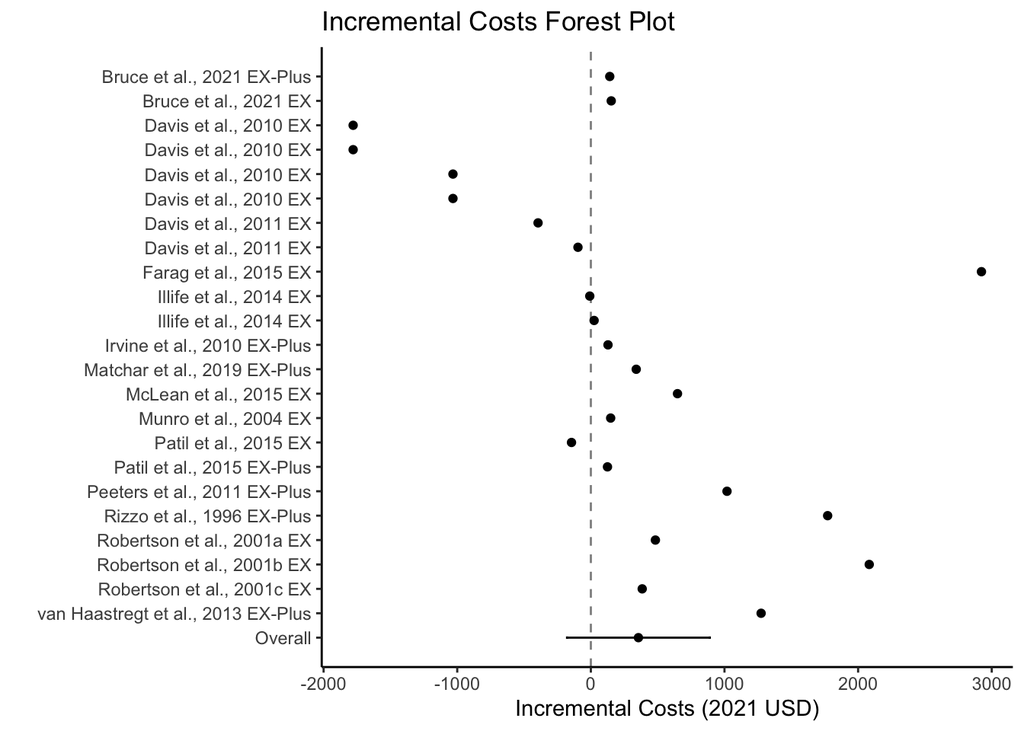

```r
forest.costs<-subset(Incremental_costs, select = c(Study_ID,Intervention_Type,Incremental_Costs,Incremental_Costs_LL95CI,
                                                   Incremental_Costs_UL95CI))
forest.costs$Effect_size<-c(2:24)
forest.costs$Study_InterventionType<-paste(forest.costs$Study_ID,forest.costs$Intervention_Type)
forest.costs$rev_ES<-rev(forest.costs$Effect_size)
Overall.effect<-c("Overall", NA, 356, -178, 890, 1, "Overall", 1)
forest.costs.plot<-rbind(forest.costs, Overall.effect)
forest.costs.plot$rev_ES<-as.numeric(forest.costs.plot$rev_ES)
forest.costs.plot$Incremental_Costs<-as.numeric(forest.costs.plot$Incremental_Costs)
forest.costs.plot$Incremental_Costs_LL95CI<-as.numeric(forest.costs.plot$Incremental_Costs_LL95CI)
forest.costs.plot$Incremental_Costs_UL95CI<-as.numeric(forest.costs.plot$Incremental_Costs_UL95CI)

Incremental.Costs.plot<-ggplot(forest.costs.plot, aes(y=rev_ES, x=Incremental_Costs, xmin=Incremental_Costs_LL95CI, xmax=Incremental_Costs_UL95CI)) +
  geom_point() + geom_errorbarh(height=.1) + scale_y_continuous(name= "", breaks=rev(1:nrow(forest.costs.plot)), labels=forest.costs.plot$Study_InterventionType) +
  labs(title="Incremental Costs Forest Plot", x="Incremental Costs (2021 USD)", y = "Author, Year, Intervention Type" ) +
  geom_vline(xintercept=0, color="black", linetype="dashed", alpha=.5) + theme_classic()

Incremental.Costs.plot
```

Incremental QALYs (Unstandardized estimates)

```r
incremental_qolys.unstandardized<-robu(Incremental_QoLYs~1, var=Incremental_QOLYs_Variance, studynum=Study_ID, Incremental_QOLYs)
print(incremental_qolys.unstandardized)
```

```
## RVE: Correlated Effects Model with Small-Sample Corrections
##
## Model: Incremental_QoLYs ~ 1
##
## Number of studies = 9
## Number of outcomes = 15 (min = 1 , mean = 1.67 , median = 1 , max = 4 )
## Rho = 0.8
## I.sq = 0
## Tau.sq = 0
##
##                Estimate StdErr t-value  dfs P(|t|>) 95% CI.L 95% CI.U Sig
## 1 X.Intercept.   0.0878 0.0469    1.87 1.22   0.277   -0.308    0.483
## ---
## Signif. codes: < .01 *** < .05 ** < .10 *
## ---
## Note: If df < 4, do not trust the results
```

```r
sensitivity(incremental_qolys.unstandardized)
```

```
## RVE: Correlated Effects Model with Small-Sample Corrections
## Model: Incremental_QoLYs ~ 1
##
## Sensitivity Analysis
##
##                           Rho = 0 Rho = 0.2 Rho = 0.4 Rho = 0.6 Rho = 0.8
##  X.Intercept. Coefficient 0.0878  0.0878    0.0878    0.0878    0.0878
##               Std. Error  0.0469  0.0469    0.0469    0.0469    0.0469
##  Tau.sq       Estimate    0.0000  0.0000    0.0000    0.0000    0.0000
##  Rho = 1
##  0.0878
##  0.0469
##  0.0000
```

Forest Plot for Incremental QALYs

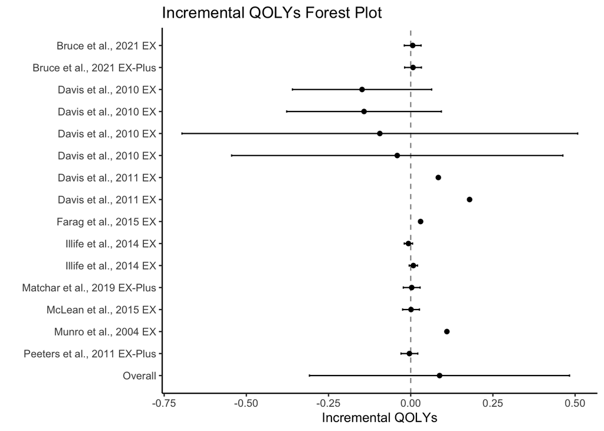

```r
forest.qolys<-subset(Incremental_QOLYs, select = c(Study_ID,Intervention_Type,Incremental_QoLYs,Incremental_QOLYs_LL95CI,
                                                   Incremental_QOLYs_UL95CI))
forest.qolys$Effect_size<-c(2:16)
forest.qolys$Study_InterventionType<-paste(forest.qolys$Study_ID,forest.qolys$Intervention_Type)
forest.qolys$rev_ES<-rev(forest.qolys$Effect_size)
Overall.effect<-c("Overall", NA, 0.0878, -0.308, 0.483, 1, "Overall", 1)
forest.qolys.plot<-rbind(forest.qolys, Overall.effect)
forest.qolys.plot$rev_ES<-as.numeric(forest.qolys.plot$rev_ES)
forest.qolys.plot$Incremental_QoLYs<-as.numeric(forest.qolys.plot$Incremental_QoLYs)
forest.qolys.plot$Incremental_QOLYs_LL95CI<-as.numeric(forest.qolys.plot$Incremental_QOLYs_LL95CI)
forest.qolys.plot$Incremental_QOLYs_UL95CI<-as.numeric(forest.qolys.plot$Incremental_QOLYs_UL95CI)

Incremental.Qolys.plot<-ggplot(forest.qolys.plot, aes(y=rev_ES, x=Incremental_QoLYs, xmin=Incremental_QOLYs_LL95CI, xmax=Incremental_QOLYs_UL95CI)) +
  geom_point() + geom_errorbarh(height=.1) + scale_y_continuous(name= "", breaks=rev(1:nrow(forest.qolys.plot)), labels=forest.qolys.plot$Study_InterventionType) +
  labs(title="Incremental QOLYs Forest Plot", x="Incremental QOLYs", y = "Author, Year, Intervention Type" ) +
  geom_vline(xintercept=0, color="black", linetype="dashed", alpha=.5) + theme_classic()

Incremental.Qolys.plot
```

Incident Rate for Falls using Hedge’s g. Estimates are re-transformed by exponentiation

```r
falls.g<-robu(IRR_of_Falls_g~1, var=IRR_of_Falls_g_var, studynum=Study_ID, IRR_Falls)
print(falls.g)
```

```
## RVE: Correlated Effects Model with Small-Sample Corrections
##
## Model: IRR_of_Falls_g ~ 1
##
## Number of studies = 10
## Number of outcomes = 15 (min = 1 , mean = 1.5 , median = 1.5 , max = 2 )
## Rho = 0.8
## I.sq = 92.16935
## Tau.sq = 0.3283823
##
##                Estimate StdErr t-value dfs P(|t|>) 95% CI.L 95% CI.U Sig
## 1 X.Intercept.   -0.665  0.163   -4.07 8.8 0.00293    -1.04   -0.294 ***
## ---
## Signif. codes: < .01 *** < .05 ** < .10 *
## ---
## Note: If df < 4, do not trust the results
```

```r
sensitivity(falls.g)
```

```
## RVE: Correlated Effects Model with Small-Sample Corrections
## Model: IRR_of_Falls_g ~ 1
##
## Sensitivity Analysis
##
##                           Rho = 0 Rho = 0.2 Rho = 0.4 Rho = 0.6 Rho = 0.8
##  X.Intercept. Coefficient -0.665  -0.665    -0.665    -0.665    -0.665
##               Std. Error   0.163   0.163     0.163     0.163     0.163
##  Tau.sq       Estimate     0.327   0.328     0.328     0.328     0.328
##  Rho = 1
##  -0.665
##   0.163
##   0.329
```

```r
irr.exp<-c(falls.g$reg_table$b.r, falls.g$reg_table$CI.L, falls.g$reg_table$CI.U)
exp(irr.exp) #Point Estimate, 95% CI LL, 95% CI UL
```

```
## [1] 0.5144590 0.3551650 0.7451975
```

Forest Plot for Incident Rate of Falls. Estimates are re-transformed by exponentiation

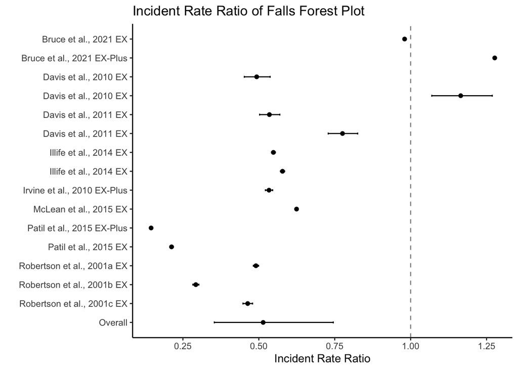

```r
forest.IRRs<-subset(IRR_Falls, select = c(Study_ID,Intervention_Type,IRR_of_Falls_g,IRR_Falls_SMD_LL95CI,
                                          IRR_Falls_SMD_UL95CI))
forest.IRRs$Effect_size<-c(2:16)
forest.IRRs$Study_InterventionType<-paste(forest.IRRs$Study_ID,forest.IRRs$Intervention_Type)
forest.IRRs$rev_ES<-rev(forest.IRRs$Effect_size)
Overall.effect<-c("Overall", NA, -0.665, -1.04, -0.294, 1, "Overall", 1)
forest.IRRs.plot<-rbind(forest.IRRs, Overall.effect)
forest.IRRs.plot$rev_ES<-as.numeric(forest.IRRs.plot$rev_ES)
forest.IRRs.plot$IRR_of_Falls_g<-as.numeric(forest.IRRs.plot$IRR_of_Falls_g)
forest.IRRs.plot$IRR_Falls_SMD_LL95CI<-as.numeric(forest.IRRs.plot$IRR_Falls_SMD_LL95CI)
forest.IRRs.plot$IRR_Falls_SMD_UL95CI<-as.numeric(forest.IRRs.plot$IRR_Falls_SMD_UL95CI)
forest.IRRs.plot$IRR_exp<-exp(forest.IRRs.plot$IRR_of_Falls_g)
forest.IRRs.plot$UL_exp<-exp(forest.IRRs.plot$IRR_Falls_SMD_UL95CI)
forest.IRRs.plot$LL_exp<-exp(forest.IRRs.plot$IRR_Falls_SMD_LL95CI)

IRR.plot<-ggplot(forest.IRRs.plot, aes(y=rev_ES, x=IRR_exp, xmin=LL_exp, xmax=UL_exp)) +
  geom_point() + geom_errorbarh(height=.1) + scale_y_continuous(name= "", breaks=rev(1:nrow(forest.IRRs.plot)), labels=forest.IRRs.plot$Study_InterventionType) +
  labs(title="Incident Rate Ratio of Falls Forest Plot", x="Incident Rate Ratio", y = "Author, Year, Intervention Type" ) +
  geom_vline(xintercept=1, color="black", linetype="dashed", alpha=.5) + theme_classic()

IRR.plot
```

# 4) Does Intervention Type (EX vs. EX-Plus) moderate the effects on incremental costs, QALYs, or incident rate of falls

Incremental Costs

```r
robu(Incremental_Costs~Intervention_Type-1, var.eff.size = Incremental_Costs_Variance, studynum = Study_ID, data = Incremental_costs)
```

```
## RVE: Correlated Effects Model with Small-Sample Corrections
##
## Model: Incremental_Costs ~ Intervention_Type - 1
##
## Number of studies = 16
## Number of outcomes = 23 (min = 1 , mean = 1.44 , median = 1 , max = 4 )
## Rho = 0.8
## I.sq = 90.14687
## Tau.sq = 458472.1
##
##                            Estimate StdErr t-value  dfs P(|t|>) 95% CI.L
## 1      Intervention_TypeEX      128    330    0.39 6.57  0.7092   -661.6
## 2 Intervention_TypeEX.Plus      786    325    2.41 4.61  0.0647    -72.3
##   95% CI.U Sig
## 1      918
## 2     1644   *
## ---
## Signif. codes: < .01 *** < .05 ** < .10 *
## ---
## Note: If df < 4, do not trust the results
```

```r
costs.mod<-robu(Incremental_Costs~Intervention_Type-1, var.eff.size = Incremental_Costs_Variance, studynum = Study_ID, data = Incremental_costs)
cpairs<- constraints<-matrix(c(1,-1), 1,2)
Wald_test(costs.mod, constraints = cpairs, vcov = "CR2", tidy = TRUE)
```

```
##  test Fstat df_num df_denom p_val sig
##   HTZ  2.03      1     9.81 0.185
```

Incremental QALYs

```r
robu(Incremental_QoLYs~Intervention_Type-1, var.eff.size = Incremental_QOLYs_Variance, studynum = Study_ID, data = Incremental_QOLYs)
```

```
## RVE: Correlated Effects Model with Small-Sample Corrections
##
## Model: Incremental_QoLYs ~ Intervention_Type - 1
##
## Number of studies = 9
## Number of outcomes = 15 (min = 1 , mean = 1.67 , median = 1 , max = 4 )
## Rho = 0.8
## I.sq = 0
## Tau.sq = 0
##
##                            Estimate  StdErr t-value  dfs P(|t|>) 95% CI.L
## 1      Intervention_TypeEX  0.08961 0.04770   1.879 1.13   0.289   -0.374
## 2 Intervention_TypeEX.Plus -0.00113 0.00342  -0.331 1.03   0.795   -0.042
##   95% CI.U Sig
## 1   0.5537
## 2   0.0397
## ---
## Signif. codes: < .01 *** < .05 ** < .10 *
## ---
## Note: If df < 4, do not trust the results
```

```r
qolys.mod<-robu(Incremental_QoLYs~Intervention_Type-1, var.eff.size = Incremental_QOLYs_Variance, studynum = Study_ID, data = Incremental_QOLYs)
cpairs<- constraints<-matrix(c(1,-1), 1,2)
Wald_test(qolys.mod, constraints = cpairs, vcov = "CR2", tidy = TRUE)
```

```
##  test Fstat df_num df_denom p_val sig
##   HTZ   3.6      1     1.07 0.296
```

Incident Rate of Falls

```r
falls.mod<-robu(IRR_of_Falls_SMD~Intervention_Type-1, var.eff.size = IRR_of_Falls_SMD_var, studynum = Study_ID, data = IRR_Falls)
falls.mod
```

```
## RVE: Correlated Effects Model with Small-Sample Corrections
##
## Model: IRR_of_Falls_SMD ~ Intervention_Type - 1
##
## Number of studies = 10
## Number of outcomes = 15 (min = 1 , mean = 1.5 , median = 1.5 , max = 2 )
## Rho = 0.8
## I.sq = 90.37246
## Tau.sq = 0.06859578
##
##                            Estimate StdErr t-value  dfs  P(|t|>) 95% CI.L
## 1      Intervention_TypeEX   -0.331 0.0603   -5.49 7.39 0.000759   -0.473
## 2 Intervention_TypeEX.Plus   -0.333 0.2215   -1.50 1.79 0.284964   -1.401
##   95% CI.U Sig
## 1   -0.190 ***
## 2    0.735
## ---
## Signif. codes: < .01 *** < .05 ** < .10 *
## ---
## Note: If df < 4, do not trust the results
```

```r
cpairs<- constraints<-matrix(c(1,-1), 1,2)
Wald_test(falls.mod, constraints = cpairs, vcov = "CR2", tidy = TRUE)
```

```
##  test    Fstat df_num df_denom p_val sig
##   HTZ 9.45e-05      1     2.75 0.993
```

```r
irr.exp<-c(falls.mod$reg_table$b.r, falls.mod$reg_table$CI.L, falls.mod$reg_table$CI.U)
irr.exp
```

```
## [1] -0.3314665 -0.3333108 -0.4726311 -1.4014324 -0.1903018  0.7348108
```

```r
exp(irr.exp) #Point Estimate EX, Point Estimate EX-Plus, 95% CI LL EX, 95% CI LL EX-Plus, 95% CI UL EX, 95% CI UL EX-Plus
```

```
## [1] 0.7178702 0.7165475 0.6233600 0.2462440 0.8267096 2.0850875
```

# 5) Funnel Plots for Publication Bias

Incremental Costs

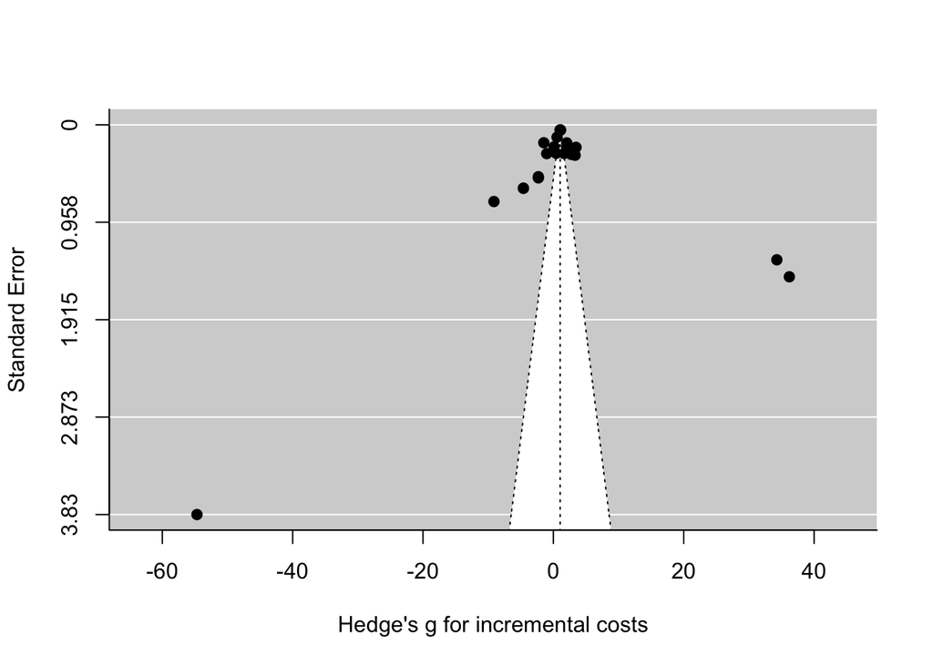

```r
meta.res.costs<-rma.mv(yi=Incremental_Costs_g,V=Incremental_Costs_g_var,data=Incremental_costs,slab=Study_ID)
funnel(meta.res.costs, xlab = "Hedge's g for incremental costs")
```

Incremental QALYs

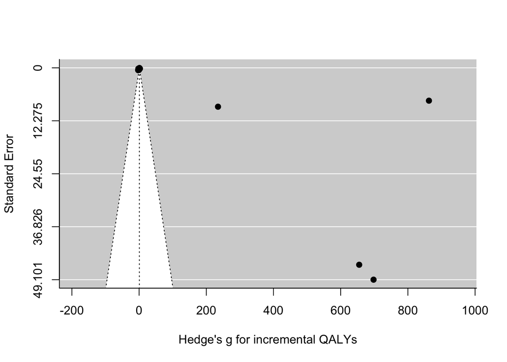

```r
meta.res.qolys<-rma.mv(yi=Incremental_QOLYs_g,V=Incremental_QOLYs_g_var,data=Incremental_QOLYs,slab=Study_ID)
funnel(meta.res.qolys, xlab = "Hedge's g for incremental QALYs")
```

Incident Rate of Falls

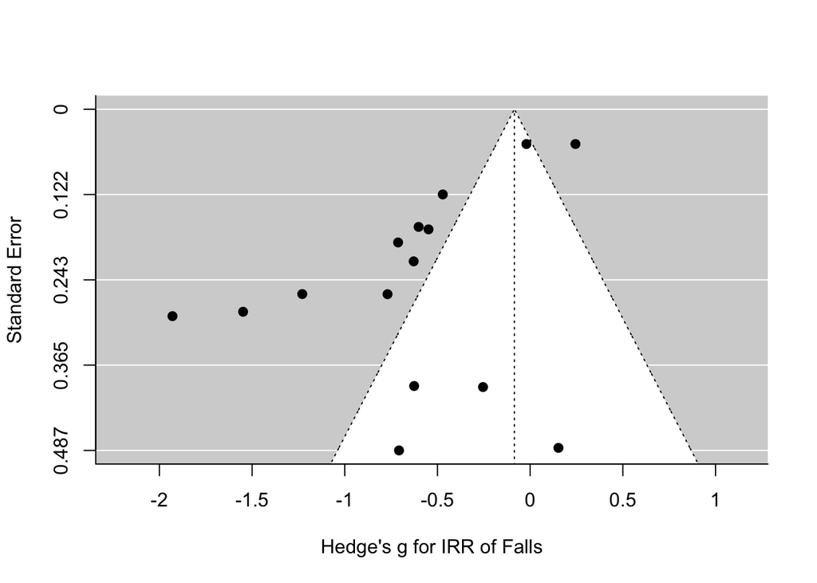

```r
meta.res.falls<-rma.mv(yi=IRR_of_Falls_g,V=IRR_of_Falls_g_var,data=IRR_Falls,slab=Study_ID)
funnel(meta.res.falls, xlab = "Hedge's g for IRR of Falls")
```

# 6) PEESE

Incremental Costs

```r
Incremental_costs$sesqrd.ES<-Incremental_costs$Incremental_Costs_g_se^2
peese.rve.costs <- robu(Incremental_Costs_g~sesqrd.ES, var.eff.size = Incremental_Costs_g_var, studynum = Study_ID, data = Incremental_costs)
print(peese.rve.costs)
```

```
## RVE: Correlated Effects Model with Small-Sample Corrections
##
## Model: Incremental_Costs_g ~ sesqrd.ES
##
## Number of studies = 16
## Number of outcomes = 23 (min = 1 , mean = 1.44 , median = 1 , max = 4 )
## Rho = 0.8
## I.sq = 99.22437
## Tau.sq = 2.702136
##
##                Estimate StdErr t-value   dfs P(|t|>)   95% CI.L 95% CI.U Sig
## 1 X.Intercept.      4.1   2.11   1.946 13.70  0.0724     -0.428     8.63   *
## 2    sesqrd.ES   -439.1 966.37  -0.454  1.07  0.7243 -10906.910 10028.62
## ---
## Signif. codes: < .01 *** < .05 ** < .10 *
## ---
## Note: If df < 4, do not trust the results
```

Incremental QALYs

```r
Incremental_QOLYs$sesqrd.ES<-Incremental_QOLYs$Incremental_QOLYs_g_se^2
peese.rve.qoly <- robu(Incremental_QOLYs_g~sesqrd.ES, var.eff.size = Incremental_QOLYs_g_var, studynum = Study_ID, data = Incremental_QOLYs)
print(peese.rve.qoly)
```

```
## RVE: Correlated Effects Model with Small-Sample Corrections
##
## Model: Incremental_QOLYs_g ~ sesqrd.ES
##
## Number of studies = 9
## Number of outcomes = 15 (min = 1 , mean = 1.67 , median = 1 , max = 4 )
## Rho = 0.8
## I.sq = 99.94752
## Tau.sq = 60.80975
##
##                Estimate StdErr t-value  dfs P(|t|>) 95% CI.L 95% CI.U Sig
## 1 X.Intercept.     77.3   67.8   1.139 6.46   0.295    -85.9      240
## 2    sesqrd.ES     44.5   52.1   0.855 1.01   0.548   -599.8      689
## ---
## Signif. codes: < .01 *** < .05 ** < .10 *
## ---
## Note: If df < 4, do not trust the results
```

Incident Rate of Falls

```r
IRR_Falls$sesqrd.ES<-IRR_Falls$IRR_of_Falls_g_se^2
peese.rve.falls <- robu(IRR_of_Falls_g~sesqrd.ES, var.eff.size = IRR_of_Falls_g_var, studynum = Study_ID, data = IRR_Falls)
print(peese.rve.falls)
```

```
## RVE: Correlated Effects Model with Small-Sample Corrections
##
## Model: IRR_of_Falls_g ~ sesqrd.ES
##
## Number of studies = 10
## Number of outcomes = 15 (min = 1 , mean = 1.5 , median = 1.5 , max = 2 )
## Rho = 0.8
## I.sq = 92.10271
## Tau.sq = 0.3177426
##
##                Estimate  StdErr t-value  dfs P(|t|>) 95% CI.L 95% CI.U Sig
## 1 X.Intercept.     -0.7   0.208  -3.372 6.94  0.0121    -1.19   -0.208  **
## 2    sesqrd.ES    113.6 229.485   0.495 1.50  0.6835 -1268.34 1495.459
## ---
## Signif. codes: < .01 *** < .05 ** < .10 *
## ---
## Note: If df < 4, do not trust the results
```

# 7) Egger’s Regression Test for Dependent Effect Sizes

Incremental Costs

```r
pet.rve.cost<-robu(Incremental_Costs_g~Incremental_Costs_g_se, var.eff.size=Incremental_Costs_g_var,
                   studynum=Study_ID, data=Incremental_costs)

print(pet.rve.cost)
```

```
## RVE: Correlated Effects Model with Small-Sample Corrections
##
## Model: Incremental_Costs_g ~ Incremental_Costs_g_se
##
## Number of studies = 16
## Number of outcomes = 23 (min = 1 , mean = 1.44 , median = 1 , max = 4 )
## Rho = 0.8
## I.sq = 99.22145
## Tau.sq = 2.817572
##
##                          Estimate StdErr t-value   dfs P(|t|>) 95% CI.L
## 1           X.Intercept.     3.53   3.69  0.9563 11.48   0.359    -4.55
## 2 Incremental_Costs_g_se    -6.87 230.64 -0.0298  1.96   0.979 -1018.00
##   95% CI.U Sig
## 1     11.6
## 2   1004.3
## ---
## Signif. codes: < .01 *** < .05 ** < .10 *
## ---
## Note: If df < 4, do not trust the results
```

Incremental QALYs

```r
pet.rve.qolys<-robu(Incremental_QOLYs_g~Incremental_QOLYs_g_se, var.eff.size=Incremental_QOLYs_g_var,
                   studynum=Study_ID, data=Incremental_QOLYs)

print(pet.rve.qolys)
```

```
## RVE: Correlated Effects Model with Small-Sample Corrections
##
## Model: Incremental_QOLYs_g ~ Incremental_QOLYs_g_se
##
## Number of studies = 9
## Number of outcomes = 15 (min = 1 , mean = 1.67 , median = 1 , max = 4 )
## Rho = 0.8
## I.sq = 99.94747
## Tau.sq = 70.21521
##
##                          Estimate StdErr t-value  dfs P(|t|>) 95% CI.L 95% CI.U
## 1           X.Intercept.     67.9   67.8    1.00 6.28   0.354    -96.3      232
## 2 Incremental_QOLYs_g_se    257.3  187.7    1.37 1.09   0.387  -1700.6     2215
##   Sig
## 1
## 2
## ---
## Signif. codes: < .01 *** < .05 ** < .10 *
## ---
## Note: If df < 4, do not trust the results
```

Incident Rate of Falls

```r
pet.rve.falls<-robu(IRR_of_Falls_g~IRR_of_Falls_g_se, var.eff.size=IRR_of_Falls_g_var,
                    studynum=Study_ID, data=IRR_Falls)

print(pet.rve.falls)
```

```
## RVE: Correlated Effects Model with Small-Sample Corrections
##
## Model: IRR_of_Falls_g ~ IRR_of_Falls_g_se
##
## Number of studies = 10
## Number of outcomes = 15 (min = 1 , mean = 1.5 , median = 1.5 , max = 2 )
## Rho = 0.8
## I.sq = 87.23982
## Tau.sq = 0.2207633
##
##                     Estimate StdErr t-value  dfs P(|t|>) 95% CI.L 95% CI.U Sig
## 1      X.Intercept.   -0.568  0.284  -2.003 4.66   0.106    -1.31    0.177
## 2 IRR_of_Falls_g_se   -6.829 17.114  -0.399 2.56   0.721   -66.94   53.281
## ---
## Signif. codes: < .01 *** < .05 ** < .10 *
## ---
## Note: If df < 4, do not trust the results
```

# 8) Leave-One-Out Analyses

Incremental Costs

```r
leave.one.out.all<- function(rownum){

  # subset dataframe
  vec <- rep(TRUE, nrow(Incremental_costs))
  vec[rownum] <- FALSE
  inf <- subset(Incremental_costs, vec)

  # fit reference model
  rve.model.ref <- robu(Incremental_Costs~1,var=Incremental_Costs_Variance,studynum=Study_ID, Incremental_costs)

  # fit adjusted model
  rve.model <- robu(Incremental_Costs~1,var=Incremental_Costs_Variance,studynum=Study_ID, data = inf)

  # return results
  results.vec <- c(ES.study = round(Incremental_costs$Incremental_Costs[rownum], 3),
                   ES.adj = round(rve.model$reg_table$b.r, 3),
                   se.ES.adj = round(rve.model$reg_table$SE, 3),
                   p.adj = round(rve.model$reg_table$prob, 5),
                   diff.ES = round(rve.model$reg_table$b.r - rve.model.ref$reg_table$b.r, 3),
                   diff.se.ES = round(rve.model$reg_table$SE - rve.model.ref$reg_table$SE, 3),
                   diff.p = round(rve.model$reg_table$prob - rve.model.ref$reg_table$prob, 5),
                   diff.isq = round(rve.model$mod_info$I.2 - rve.model.ref$mod_info$I.2, 3))
  return(results.vec)
}

inf.all <- sapply(1:nrow(Incremental_costs), leave.one.out.all)
inf.all <- data.frame(t(inf.all))
inf.all <- data.frame(label = paste(Incremental_costs$Study_ID, Incremental_costs$Intervention_Type, sep = " / "),
                      inf.all)
inf.all$z.ES.study <- round(scale(inf.all$ES.study), 2)

inf.all
```

```
##                                   label ES.study  ES.adj se.ES.adj   p.adj
## 1          Bruce et al., 2021 / EX-Plus   141.37 385.759   250.872 0.15212
## 2               Bruce et al., 2021 / EX   152.46 385.641   250.870 0.15223
## 3               Davis et al., 2010 / EX -1779.00 395.376   244.722 0.13429
## 4               Davis et al., 2010 / EX -1779.00 395.376   244.722 0.13429
## 5               Davis et al., 2010 / EX -1032.00 375.942   257.410 0.17178
## 6               Davis et al., 2010 / EX -1032.00 375.942   257.410 0.17178
## 7               Davis et al., 2011 / EX  -395.15 393.378   247.003 0.13997
## 8               Davis et al., 2011 / EX   -96.52 376.683   255.206 0.16727
## 9               Farag et al., 2015 / EX  2923.00 381.218   251.187 0.15713
## 10             Illife et al., 2014 / EX    -8.11 389.935   250.900 0.14800
## 11             Illife et al., 2014 / EX    24.35 379.469   250.873 0.15862
## 12        Irvine et al., 2010 / EX-Plus   128.28 452.751   272.950 0.12484
## 13       Matchar et al., 2019 / EX-Plus   339.50 391.281   274.651 0.18429
## 14             McLean et al., 2015 / EX   648.30 382.961   253.800 0.15986
```

[output cut: 33 more lines]

Incremental QALYs

```r
leave.one.out.all.qoly<- function(rownum){

  # subset dataframe
  vec <- rep(TRUE, nrow(Incremental_QOLYs))
  vec[rownum] <- FALSE
  inf <- subset(Incremental_QOLYs, vec)

  # fit reference model
  rve.model.ref <- robu(Incremental_QoLYs~1,var=Incremental_QOLYs_Variance,studynum=Study_ID, Incremental_QOLYs)

  # fit adjusted model
  rve.model <- robu(Incremental_QoLYs~1,var=Incremental_QOLYs_Variance,studynum=Study_ID, data = inf)

  # return results
  results.vec <- c(ES.study = round(Incremental_QOLYs$Incremental_QoLYs[rownum], 3),
                   ES.adj = round(rve.model$reg_table$b.r, 3),
                   se.ES.adj = round(rve.model$reg_table$SE, 3),
                   p.adj = round(rve.model$reg_table$prob, 5),
                   diff.ES = round(rve.model$reg_table$b.r - rve.model.ref$reg_table$b.r, 3),
                   diff.se.ES = round(rve.model$reg_table$SE - rve.model.ref$reg_table$SE, 3),
                   diff.p = round(rve.model$reg_table$prob - rve.model.ref$reg_table$prob, 5),
                   diff.isq = round(rve.model$mod_info$I.2 - rve.model.ref$mod_info$I.2, 3))
  return(results.vec)
}

inf.all <- sapply(1:nrow(Incremental_QOLYs), leave.one.out.all.qoly)
inf.all <- data.frame(t(inf.all))
inf.all <- data.frame(label = paste(Incremental_QOLYs$Study_ID, Incremental_QOLYs$Intervention_Type, sep = " / "),
                      inf.all)
inf.all$z.ES.study <- round(scale(inf.all$ES.study), 2)

inf.all
```

```
##                             label ES.study ES.adj se.ES.adj   p.adj diff.ES
## 1         Bruce et al., 2021 / EX    0.006  0.088     0.047 0.27678   0.000
## 2    Bruce et al., 2021 / EX-Plus    0.007  0.088     0.047 0.27678   0.000
## 3         Davis et al., 2010 / EX   -0.148  0.088     0.047 0.27670   0.000
## 4         Davis et al., 2010 / EX   -0.142  0.088     0.047 0.27671   0.000
## 5         Davis et al., 2010 / EX   -0.094  0.088     0.047 0.27682   0.000
## 6         Davis et al., 2010 / EX   -0.041  0.088     0.047 0.27696   0.000
## 7         Davis et al., 2011 / EX    0.084  0.104     0.068 0.33257   0.016
## 8         Davis et al., 2011 / EX    0.179  0.066     0.024 0.19328  -0.022
## 9         Farag et al., 2015 / EX    0.030  0.124     0.024 0.10020   0.036
## 10       Illife et al., 2014 / EX   -0.007  0.088     0.047 0.27653   0.000
## 11       Illife et al., 2014 / EX    0.008  0.088     0.047 0.27704   0.000
## 12 Matchar et al., 2019 / EX-Plus    0.003  0.088     0.047 0.28162   0.001
## 13       McLean et al., 2015 / EX    0.001  0.088     0.047 0.27818   0.000
## 14        Munro et al., 2004 / EX    0.110  0.087     0.049 0.30136   0.000
```

[output cut: 17 more lines]

Incident Rate of Falls

```r
leave.one.out.all.falls<- function(rownum){

  # subset dataframe
  vec <- rep(TRUE, nrow(IRR_Falls))
  vec[rownum] <- FALSE
  inf <- subset(IRR_Falls, vec)

  # fit reference model
  rve.model.ref <- robu(IRR_of_Falls_g~1,var=IRR_of_Falls_g_var,studynum=Study_ID, IRR_Falls)

  # fit adjusted model
  rve.model <- robu(IRR_of_Falls_g~1,var=IRR_of_Falls_g_var,studynum=Study_ID, data = inf)

  # return results
  results.vec <- c(ES.study = round(IRR_Falls$IRR_of_Falls_g[rownum], 3),
                   ES.adj = round(rve.model$reg_table$b.r, 3),
                   se.ES.adj = round(rve.model$reg_table$SE, 3),
                   p.adj = round(rve.model$reg_table$prob, 5),
                   diff.ES = round(rve.model$reg_table$b.r - rve.model.ref$reg_table$b.r, 3),
                   diff.se.ES = round(rve.model$reg_table$SE - rve.model.ref$reg_table$SE, 3),
                   diff.p = round(rve.model$reg_table$prob - rve.model.ref$reg_table$prob, 5),
                   diff.isq = round(rve.model$mod_info$I.2 - rve.model.ref$mod_info$I.2, 3))
  return(results.vec)
}

inf.all <- sapply(1:nrow(IRR_Falls), leave.one.out.all.falls)
inf.all <- data.frame(t(inf.all))
inf.all <- data.frame(label = paste(IRR_Falls$Study_ID, IRR_Falls$Intervention_Type, sep = " / "),
                      inf.all)
inf.all$z.ES.study <- round(scale(inf.all$ES.study), 2)

inf.all
```

```
##                            label ES.study ES.adj se.ES.adj   p.adj diff.ES
## 1        Bruce et al., 2021 / EX   -0.020 -0.652     0.173 0.00452   0.013
## 2   Bruce et al., 2021 / EX-Plus    0.244 -0.675     0.154 0.00192  -0.010
## 3        Davis et al., 2010 / EX   -0.707 -0.634     0.171 0.00502   0.030
## 4        Davis et al., 2010 / EX    0.153 -0.695     0.161 0.00206  -0.030
## 5        Davis et al., 2011 / EX   -0.626 -0.650     0.166 0.00365   0.015
## 6        Davis et al., 2011 / EX   -0.254 -0.680     0.162 0.00246  -0.015
## 7       Illife et al., 2014 / EX   -0.602 -0.662     0.163 0.00303   0.003
## 8       Illife et al., 2014 / EX   -0.548 -0.668     0.163 0.00283  -0.003
## 9  Irvine et al., 2010 / EX-Plus   -0.628 -0.670     0.183 0.00673  -0.005
## 10      McLean et al., 2015 / EX   -0.471 -0.692     0.182 0.00543  -0.028
## 11  Patil et al., 2015 / EX-Plus   -1.929 -0.646     0.151 0.00222   0.019
## 12       Patil et al., 2015 / EX   -1.549 -0.683     0.176 0.00388  -0.018
## 13  Robertson et al., 2001a / EX   -0.712 -0.660     0.184 0.00739   0.005
## 14  Robertson et al., 2001b / EX   -1.229 -0.601     0.168 0.00753   0.063
```

[output cut: 17 more lines]

# 9) Do the effects differ if Farag et al. and Patil et al. are excluded from the meta?

Both studies had incremental costs estimated using ICER data.

Mark studies with estimated (i.e., Farag et al. and Patil et al.) versus reported incremental costs

```r
Incremental_costs$ES_calculation<-NA
Incremental_costs$ES_calculation[Incremental_costs$Study_ID=="Farag et al., 2015" |
                                   Incremental_costs$Study_ID=="Patil et al., 2015" ]<-"Estimated"
Incremental_costs$ES_calculation[Incremental_costs$Study_ID!="Farag et al., 2015" &
                                   Incremental_costs$Study_ID!="Patil et al., 2015" ]<-"Reported"
```

Moderation effect for determining if effect is different when excluding studies with estimated incremental costs

```r
robu(Incremental_Costs~ES_calculation-1, var.eff.size = Incremental_Costs_Variance, studynum = Study_ID, data = Incremental_costs)
```

```
## RVE: Correlated Effects Model with Small-Sample Corrections
##
## Model: Incremental_Costs ~ ES_calculation - 1
##
## Number of studies = 16
## Number of outcomes = 23 (min = 1 , mean = 1.44 , median = 1 , max = 4 )
## Rho = 0.8
## I.sq = 92.57565
## Tau.sq = 303168.3
##
##                           Estimate StdErr t-value  dfs P(|t|>) 95% CI.L
## 1 ES_calculationEstimated     66.9    469   0.142  1.0   0.910    -5897
## 2  ES_calculationReported    410.8    270   1.524 10.1   0.158     -189
##   95% CI.U Sig
## 1     6031
## 2     1010
## ---
## Signif. codes: < .01 *** < .05 ** < .10 *
## ---
## Note: If df < 4, do not trust the results
```